# Univariate Plots Section

```
##
##  Pearson's product-moment correlation
##
## data:  rw$fixed.acidity and rw$density
## t = 35.877, df = 1597, p-value < 2.2e-16
## alternative hypothesis: true correlation is not equal to 0
## 95 percent confidence interval:
##  0.6399847 0.6943302
## sample estimates:
##       cor
## 0.6680473
```

Density is positively correlated with fixed acidity with a correlation coefficient of 0.668. As fixed acidity increases, density increases.

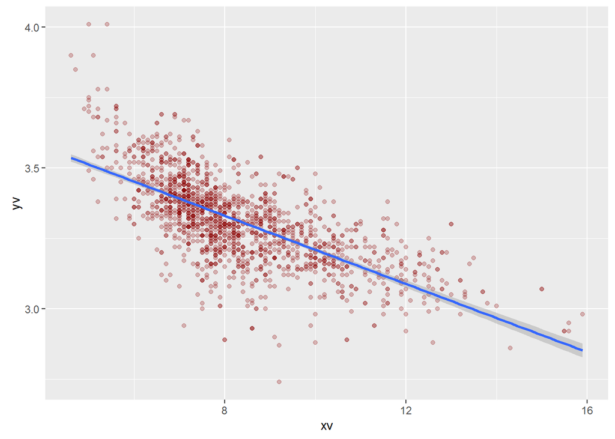

```
##
##  Pearson's product-moment correlation
##
## data:  rw$fixed.acidity and rw$pH
## t = -37.366, df = 1597, p-value < 2.2e-16
## alternative hypothesis: true correlation is not equal to 0
## 95 percent confidence interval:
##  -0.7082857 -0.6559174
## sample estimates:
##        cor
## -0.6829782
```

pH is negatively correlated with fixed acidity with a correlation coefficient of -0.683. As fixed acidity increases, pH decreases.

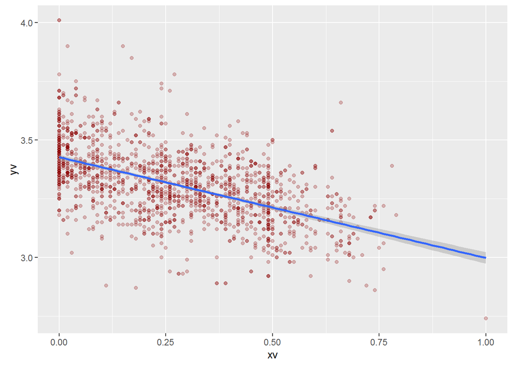

```
##
##  Pearson's product-moment correlation
##
## data:  rw$citric.acid and rw$pH
## t = -25.767, df = 1597, p-value < 2.2e-16
## alternative hypothesis: true correlation is not equal to 0
## 95 percent confidence interval:
##  -0.5756337 -0.5063336
## sample estimates:
##        cor
## -0.5419041
```

pH is negatively correlated with citric acid with aa correlation coefficient of -0.542. As citric acid increases, pH descreases.

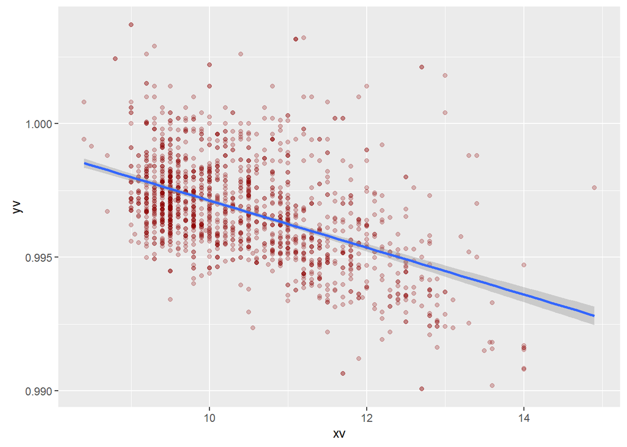

```
##
##  Pearson's product-moment correlation
##
## data:  rw$alcohol and rw$density
## t = -22.838, df = 1597, p-value < 2.2e-16
## alternative hypothesis: true correlation is not equal to 0
## 95 percent confidence interval:
##  -0.5322547 -0.4583061
## sample estimates:
##        cor
## -0.4961798
```

Density is negatively correlated with alcohol with a correlation coefficient of -0.496. As alcohol increases, density decreases.

# Bivariate Analysis

### Talk about some of the relationships you observed in this part of the investigation. How did the feature(s) of interest vary with other features in the dataset?

I observed a potential relationship between a few of the variables and wine category. Good wines seem to have a higher fixed acidity and citric acidity while bad wines seem to have a higher volatile acidity. Bad wines seem to have a higher pH in general. Good wines had more alcohol. Good wines are slightly less dense and have slightly more sulphates. There did not seem to be any difference in residual sugars. Total and free sulfur dioxide seemed to be lower in both bad and good wines than in fair wines.

### Did you observe any interesting relationships between the other features (not the main feature(s) of interest)?

Most of the correlations observed were as expected. Citric acid is related to fixed acidity, volatile acidity, and pH. Free sulfur dioxide and total sulfur dioxide were positively correlated. Fixed acidity and pH were correlated as expected, but surprisingly not volatile acidity and pH. Density was positively correlated with fixed acidity and negatively correlated with alcohol.

### What was the strongest relationship you found?

The strongest relationship was between fixed acidity and pH at -0.683.

# Multivariate Plots Section

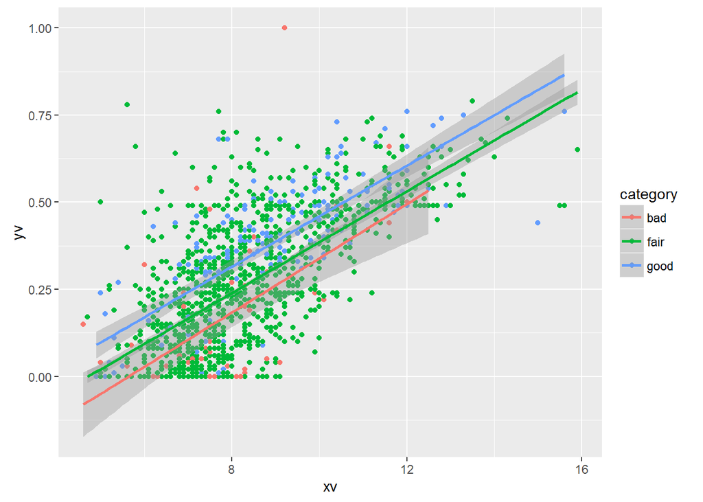

```
##
##  Pearson's product-moment correlation
##
## data:  rwgood$fixed.acidity and rwgood$citric.acid
## t = 16.39, df = 215, p-value < 2.2e-16
## alternative hypothesis: true correlation is not equal to 0
## 95 percent confidence interval:
##  0.6795463 0.7991412
## sample estimates:
##       cor
## 0.7452792
```

```
##
##  Pearson's product-moment correlation
##
## data:  rwfair$fixed.acidity and rwfair$citric.acid
## t = 31.315, df = 1317, p-value < 2.2e-16
## alternative hypothesis: true correlation is not equal to 0
## 95 percent confidence interval:
##  0.6212255 0.6831808
## sample estimates:
##       cor
## 0.6532955
```

```
##
##  Pearson's product-moment correlation
##
## data:  rwbad$fixed.acidity and rwbad$citric.acid
## t = 6.1469, df = 61, p-value = 6.61e-08
## alternative hypothesis: true correlation is not equal to 0
## 95 percent confidence interval:
##  0.4377785 0.7511286
## sample estimates:
##       cor
## 0.6184614
```

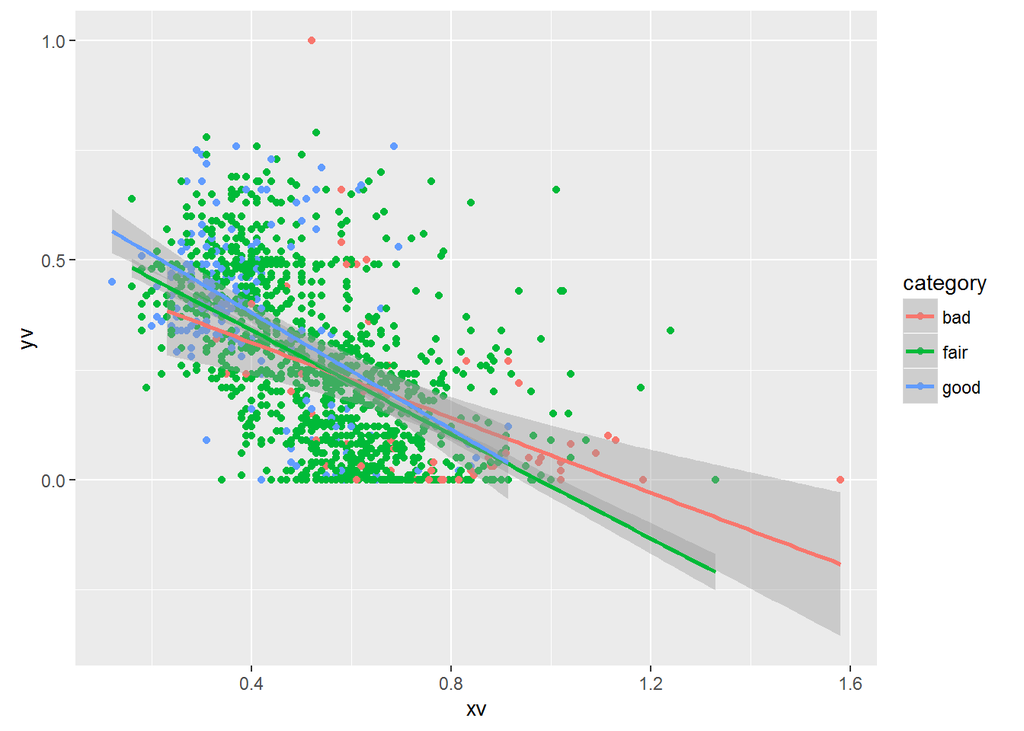

```
##
##  Pearson's product-moment correlation
##
## data:  rwgood$volatile.acidity and rwgood$citric.acid
## t = -8.3488, df = 215, p-value = 8.413e-15
## alternative hypothesis: true correlation is not equal to 0
## 95 percent confidence interval:
##  -0.5891573 -0.3871249
## sample estimates:
##       cor
## -0.494798
```

```
##
##  Pearson's product-moment correlation
##
## data:  rwfair$volatile.acidity and rwfair$citric.acid
## t = -22.606, df = 1317, p-value < 2.2e-16
## alternative hypothesis: true correlation is not equal to 0
## 95 percent confidence interval:
##  -0.5665378 -0.4887015
## sample estimates:
##        cor
## -0.5287303
```

```
##
##  Pearson's product-moment correlation
##
## data:  rwbad$volatile.acidity and rwbad$citric.acid
## t = -4.6531, df = 61, p-value = 1.808e-05
## alternative hypothesis: true correlation is not equal to 0
## 95 percent confidence interval:
##  -0.6740989 -0.3023987
## sample estimates:
##        cor
## -0.5118165
```

This graph shows that as citric acid increases, volatile acidity decreases. The correlation is about as strong in the three categories of wine (good r = -0.495, fair r = -0.529, bad r = -0.512).

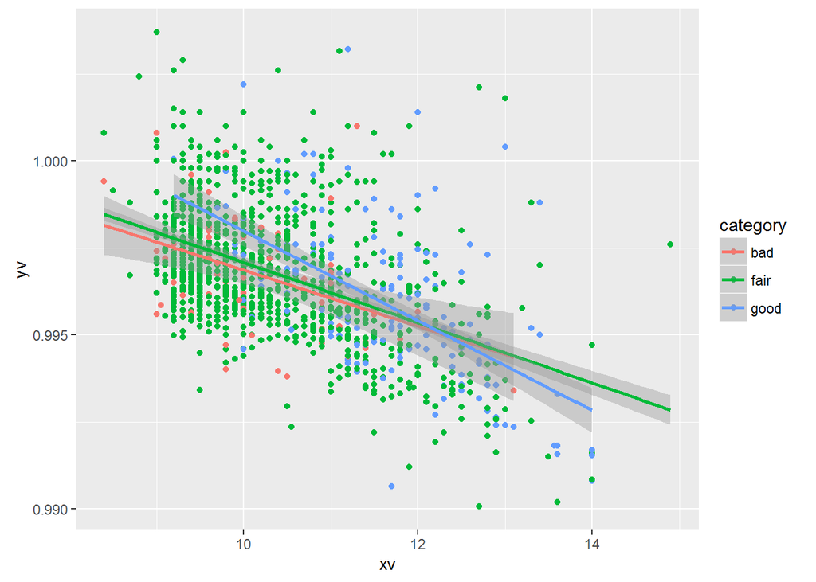

```
##
##  Pearson's product-moment correlation
##
## data:  rwgood$alcohol and rwgood$density
## t = -10.552, df = 215, p-value < 2.2e-16
## alternative hypothesis: true correlation is not equal to 0
## 95 percent confidence interval:
##  -0.6655265 -0.4889722
## sample estimates:
##        cor
## -0.5841169
```

```
##
##  Pearson's product-moment correlation
##
## data:  rwfair$alcohol and rwfair$density
## t = -18.997, df = 1317, p-value < 2.2e-16
## alternative hypothesis: true correlation is not equal to 0
## 95 percent confidence interval:
##  -0.5050954 -0.4203088
## sample estimates:
##        cor
## -0.4637633
```

```
##
##  Pearson's product-moment correlation
##
## data:  rwbad$alcohol and rwbad$density
## t = -3.8694, df = 61, p-value = 0.000268
## alternative hypothesis: true correlation is not equal to 0
## 95 percent confidence interval:
##  -0.6231524 -0.2204051
## sample estimates:
##        cor
## -0.4439278
```

The correlation between alcohol and density is a little stronger in good wine (r = -0.584) than in fair (r = -0.464) or bad (r = -0.444).

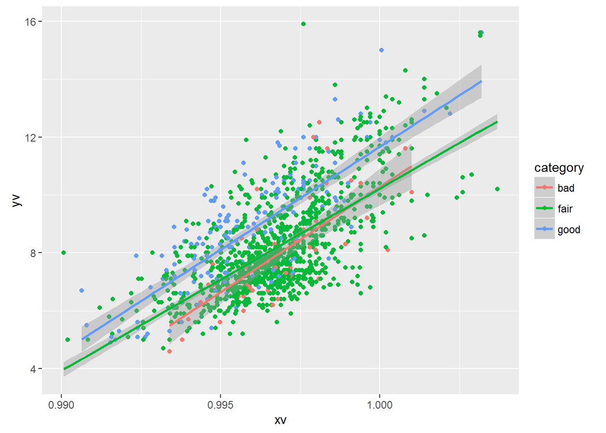

```
##
##  Pearson's product-moment correlation
##
## data:  rwgood$fixed.acidity and rwgood$density
## t = 18.38, df = 215, p-value < 2.2e-16
## alternative hypothesis: true correlation is not equal to 0
## 95 percent confidence interval:
##  0.7239057 0.8286346
## sample estimates:
##       cor
## 0.7817219
```

```
##
##  Pearson's product-moment correlation
##
## data:  rwfair$fixed.acidity and rwfair$density
## t = 33.488, df = 1317, p-value < 2.2e-16
## alternative hypothesis: true correlation is not equal to 0
## 95 percent confidence interval:
##  0.6479013 0.7062838
## sample estimates:
##       cor
## 0.6781611
```

```
##
##  Pearson's product-moment correlation
##
## data:  rwbad$fixed.acidity and rwbad$density
## t = 8.4192, df = 61, p-value = 8.381e-12
## alternative hypothesis: true correlation is not equal to 0
## 95 percent confidence interval:
##  0.5930898 0.8301068
## sample estimates:
##       cor
## 0.7331245
```

The correlation betweem fixed acidity and density again is stronger in good wine (r = 0.782) than fair (r = 0.678) or bad (r = 0.733).

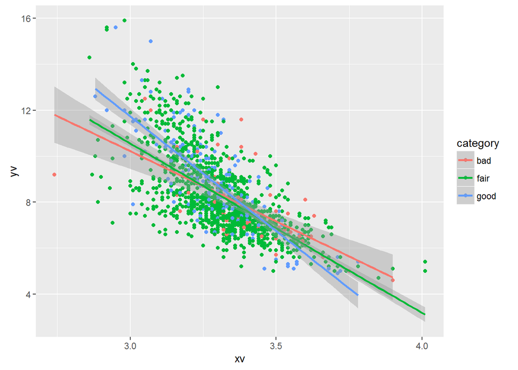

```
##
##  Pearson's product-moment correlation
##
## data:  rwgood$fixed.acidity and rwgood$pH
## t = -17.766, df = 215, p-value < 2.2e-16
## alternative hypothesis: true correlation is not equal to 0
## 95 percent confidence interval:
##  -0.8201797 -0.7110999
## sample estimates:
##       cor
## -0.771242
```

```
##
##  Pearson's product-moment correlation
##
## data:  rwfair$fixed.acidity and rwfair$pH
## t = -32.558, df = 1317, p-value < 2.2e-16
## alternative hypothesis: true correlation is not equal to 0
## 95 percent confidence interval:
##  -0.6966562 -0.6367674
## sample estimates:
##        cor
## -0.6677911
```

```
##
##  Pearson's product-moment correlation
##
## data:  rwbad$fixed.acidity and rwbad$pH
## t = -6.6559, df = 61, p-value = 9.011e-09
## alternative hypothesis: true correlation is not equal to 0
## 95 percent confidence interval:
##  -0.7722776 -0.4776121
## sample estimates:
##        cor
## -0.6486221
```

Again, a stronger correlation can be found in good wine for fixed acidity and pH (r = -0.771), than can be found in fair (r = -0.668) or bad (r = -0.649).

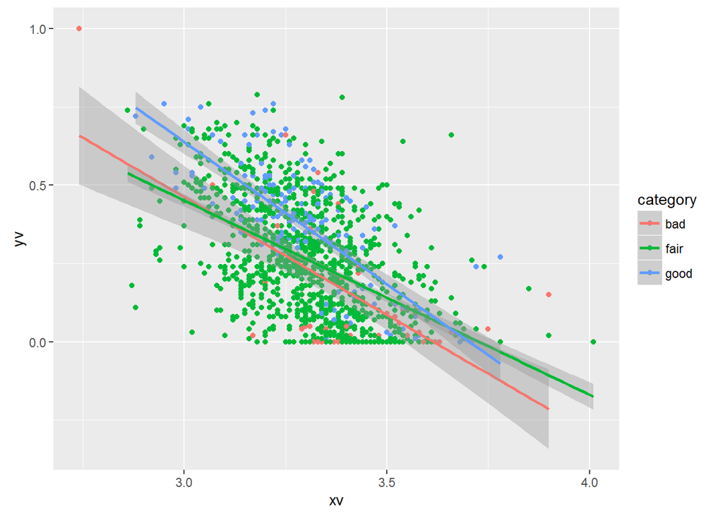

```
##
##  Pearson's product-moment correlation
##
## data:  rwgood$pH and rwgood$citric.acid
## t = -15.26, df = 215, p-value < 2.2e-16
## alternative hypothesis: true correlation is not equal to 0
## 95 percent confidence interval:
##  -0.7794057 -0.6503437
## sample estimates:
##       cor
## -0.721072
```

```
##
##  Pearson's product-moment correlation
##
## data:  rwfair$pH and rwfair$citric.acid
## t = -21.098, df = 1317, p-value < 2.2e-16
## alternative hypothesis: true correlation is not equal to 0
## 95 percent confidence interval:
##  -0.5418820 -0.4611412
## sample estimates:
##        cor
## -0.5026068
```

```
##
##  Pearson's product-moment correlation
##
## data:  rwbad$pH and rwbad$citric.acid
## t = -6.4332, df = 61, p-value = 2.161e-08
## alternative hypothesis: true correlation is not equal to 0
## 95 percent confidence interval:
##  -0.7633063 -0.4605656
## sample estimates:
##        cor
## -0.6357804
```

A stronger correlation is found between pH and citric acid for good wine (r = -0.721), than fair (r = -0.503) or bad (r = -0.636).

# Multivariate Analysis

### Talk about some of the relationships you observed in this part of the investigation. Were there features that strengthened each other in terms of looking at your feature(s) of interest?

The relationships in the multivariate analysis supported the findings in the bivariate analysis. Good wines had more citric acid and more fixed acidity. Citric acid is positively correlated with fixed acidity. Good wines have less volatile acidity and more citric acid. Volatile acidity is negatively correlated with citric acid. Good wines had more alcohol and less density. Alcohol is negatively correlated with density. Good wines have less density and more fixed acidity. Fixed acidity is positively correlated with density. Good wines have a lower pH and higher fixed acidity. Fixed acidity is negatively correlated with pH. Good wines have a lower pH and more citric acid. Citric acid is negatively correlated with pH.

### Were there any interesting or surprising interactions between features?

Fixed acidity is positively correlated with density, yet good wines tend to be lower in density and higher fixed acidity. One might think that based on the correlation, good wines would be higher in both.

### OPTIONAL: Did you create any models with your dataset? Discuss the strengths and limitations of your model.

I did not create any multivariate models.

# Final Plots and Summary

### Plot One

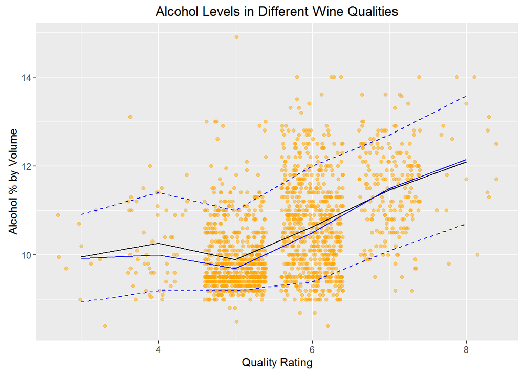

```
##    Min. 1st Qu.  Median    Mean 3rd Qu.    Max.
##   8.400   9.725   9.925   9.955  10.580  11.000
```

```
##    Min. 1st Qu.  Median    Mean 3rd Qu.    Max.
##    9.80   11.32   12.15   12.09   12.88   14.00
```

### Plot Two

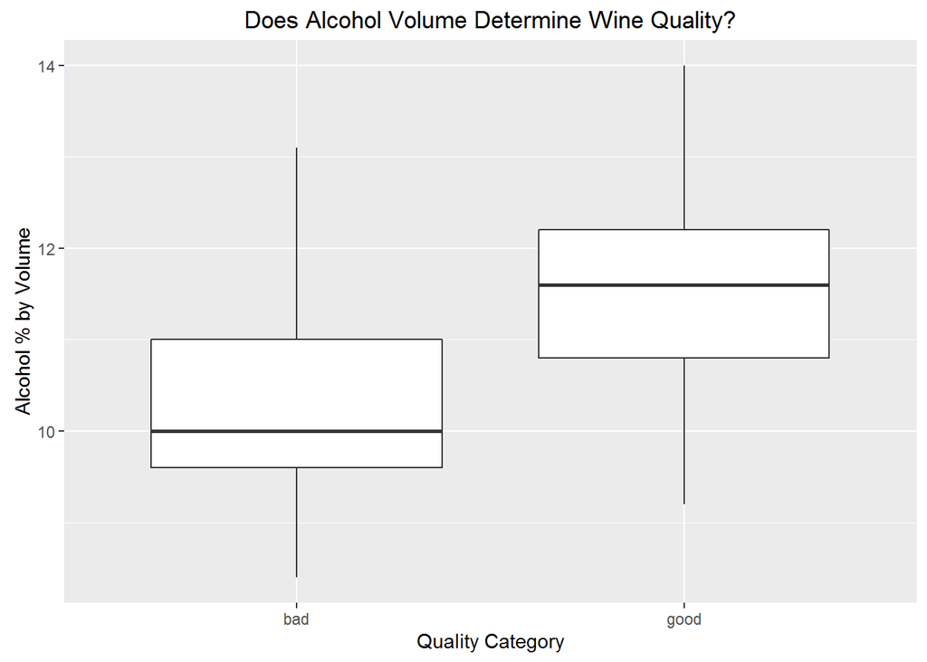

```
## [1] 11.51805
```

```
## [1] 10.21587
```

### Plot Three

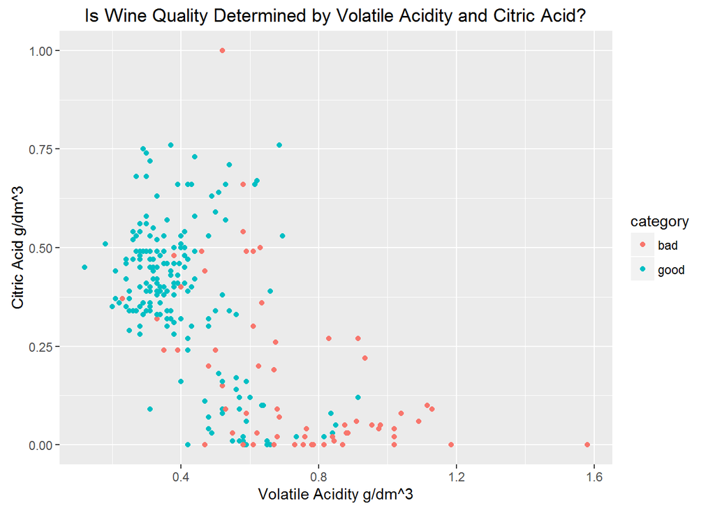

```
## [1] 0.3764977
```

```
## [1] 0.40553
```

```
## [1] 0.1736508
```

```
## [1] 0.7242063
```

### Description Three

Again, I removed fair wines to more clearly demonstrate the qualities of bad versus good wines. In this plot, we can see that good wines tend to have lower volatile acidity (0.406 g/dm^3) and higher citric acid (0.376 g/dm^3) than bad wines(0.724 g/dm^3 and 0.174 g/dm^3 respectively).

# Reflection

Deciding what graphs were the most telling was difficult. Doing the initial exploration of the characteristicts was time consuming but using a function speeded up the process a bit. Drawing conclusions from the data was difficult since most of the charcteristics of wine do not appear to be correlated to wine quality. However, I believe that dividing the wines into good and bad wines made the differing characteristics more apparent.

I think the findings are interesting enough to warrant an experiment with wines measuring for and controlling these characteristics in a doubleblind taste test. Data analysis might also explore characteristics of wines of different regions and include more wines of differing qualities.